# R notebook HW03

Afreen Alam

09 July 2020

Homework 03: R Markdown

Part 1: An R Notebook case study

Load the packages.

```r
library(tidyverse)
library(knitr)
library(xtable)
```

Special data set- anscombe viewed

```r
anscombe
```

| x1 | x2 | x3 | x4 | y1 | y2 | y3 | y4 |
| --- | --- | --- | --- | --- | --- | --- | --- |
| 10 | 10 | 10 | 8 | 8.04 | 9.14 | 7.46 | 6.58 |
| 8 | 8 | 8 | 8 | 6.95 | 8.14 | 6.77 | 5.76 |
| 13 | 13 | 13 | 8 | 7.58 | 8.74 | 12.74 | 7.71 |
| 9 | 9 | 9 | 8 | 8.81 | 8.77 | 7.11 | 8.84 |
| 11 | 11 | 11 | 8 | 8.33 | 9.26 | 7.81 | 8.47 |
| 14 | 14 | 14 | 8 | 9.96 | 8.10 | 8.84 | 7.04 |
| 6 | 6 | 6 | 8 | 7.24 | 6.13 | 6.08 | 5.25 |
| 4 | 4 | 4 | 19 | 4.26 | 3.10 | 5.39 | 12.50 |
| 12 | 12 | 12 | 8 | 10.84 | 9.13 | 8.15 | 5.56 |
| 7 | 7 | 7 | 8 | 4.82 | 7.26 | 6.42 | 7.91 |

[output cut: 1 more lines]

Wrangle the data

```r
ansc <-
  bind_cols(
    anscombe %>%
      select(matches("x")) %>%
      gather(dataset, "x"),
    anscombe %>%
      select(matches("y")) %>%
      gather(key,"y")
  ) %>%
  select(-key) %>%
  mutate(dataset = gsub("x","", dataset)) %>%
  as_tibble()
```

View the wrangled data set

```r
ansc
```

| dataset | x | y |
| --- | --- | --- |
| 1 | 10 | 8.04 |
| 1 | 8 | 6.95 |
| 1 | 13 | 7.58 |
| 1 | 9 | 8.81 |
| 1 | 11 | 8.33 |
| 1 | 14 | 9.96 |
| 1 | 6 | 7.24 |
| 1 | 4 | 4.26 |
| 1 | 12 | 10.84 |
| 1 | 7 | 4.82 |

[output cut: 34 more lines]

Performing some calculations

```r
ansc %>%
  group_by(dataset) %>%
  summarize(
    mean_x = mean(x),
    stdev_x = sd(x),
    mean_y = mean(y),
    stdev_y = sd(y)
  )
```

| dataset | mean_x | stdev_x | mean_y | stdev_y |
| --- | --- | --- | --- | --- |
| 1 | 9 | 3.316625 | 7.500909 | 2.031568 |
| 2 | 9 | 3.316625 | 7.500909 | 2.031657 |
| 3 | 9 | 3.316625 | 7.500000 | 2.030424 |
| 4 | 9 | 3.316625 | 7.500909 | 2.030579 |

Visualize the Data

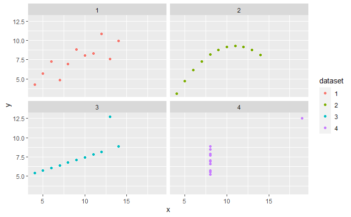

```r
ansc %>% ggplot(aes(x, y, color = dataset)) + geom_point() + facet_wrap(~dataset, ncol = 2)
```

Part 2: Two more R Markdown tricks

View first few rows of iris

```r
head(iris)
```

|  | Sepal.Length | Sepal.Width | Petal.Length | Petal.Width | Species |
| --- | --- | --- | --- | --- | --- |
| 1 | 5.1 | 3.5 | 1.4 | 0.2 | setosa |
| 2 | 4.9 | 3.0 | 1.4 | 0.2 | setosa |
| 3 | 4.7 | 3.2 | 1.3 | 0.2 | setosa |
| 4 | 4.6 | 3.1 | 1.5 | 0.2 | setosa |
| 5 | 5.0 | 3.6 | 1.4 | 0.2 | setosa |
| 6 | 5.4 | 3.9 | 1.7 | 0.4 | setosa |

Using kable to align and name the columns

```r
kable(head(iris),
      align = c("l", "c", "r", "c", "l"),
      col.names = c("Sepal Length", "Sepal Width", "Sepal Length", "Sepal Width", "Species"))
```

| Sepal Length | Sepal Width | Sepal Length | Sepal Width | Species |
| --- | --- | --- | --- | --- |
| 5.1 | 3.5 | 1.4 | 0.2 | setosa |
| 4.9 | 3.0 | 1.4 | 0.2 | setosa |
| 4.7 | 3.2 | 1.3 | 0.2 | setosa |
| 4.6 | 3.1 | 1.5 | 0.2 | setosa |
| 5.0 | 3.6 | 1.4 | 0.2 | setosa |
| 5.4 | 3.9 | 1.7 | 0.4 | setosa |

View first few rows of airquality

```r
head(airquality)
```

|  | Ozone | Solar.R | Wind | Temp | Month | Day |
| --- | --- | --- | --- | --- | --- | --- |
| 1 | 41 | 190 | 7.4 | 67 | 5 | 1 |
| 2 | 36 | 118 | 8.0 | 72 | 5 | 2 |
| 3 | 12 | 149 | 12.6 | 74 | 5 | 3 |
| 4 | 18 | 313 | 11.5 | 62 | 5 | 4 |
| 5 | NA | NA | 14.3 | 56 | 5 | 5 |
| 6 | 28 | NA | 14.9 | 66 | 5 | 6 |

Using kable to align and rename the columns

```r
kable(head(airquality),
      align = c("r", "r", "c", "c", "l", "l"),
      col.names = c("Ozone (ppb)", "Solar R (lang)", "Wind (mph)", "Temp (°F)", "Month", "Day"))
```

| Ozone (ppb) | Solar R (lang) | Wind (mph) | Temp (°F) | Month | Day |
| --- | --- | --- | --- | --- | --- |
| 41 | 190 | 7.4 | 67 | 5 | 1 |
| 36 | 118 | 8.0 | 72 | 5 | 2 |
| 12 | 149 | 12.6 | 74 | 5 | 3 |
| 18 | 313 | 11.5 | 62 | 5 | 4 |
| NA | NA | 14.3 | 56 | 5 | 5 |
| 28 | NA | 14.9 | 66 | 5 | 6 |

Quick statistical test to see if there is a significant relationship between weight and feed

```r
chicks_lm <- lm(weight ~ feed, data = chickwts)
summary(chicks_lm)
```

```
Call:
lm(formula = weight ~ feed, data = chickwts)

Residuals:
     Min       1Q   Median       3Q      Max
-123.909  -34.413    1.571   38.170  103.091

Coefficients:
              Estimate Std. Error t value Pr(>|t|)
(Intercept)    323.583     15.834  20.436  < 2e-16 ***
feedhorsebean -163.383     23.485  -6.957 2.07e-09 ***
feedlinseed   -104.833     22.393  -4.682 1.49e-05 ***
feedmeatmeal   -46.674     22.896  -2.039 0.045567 *
feedsoybean    -77.155     21.578  -3.576 0.000665 ***
feedsunflower    5.333     22.393   0.238 0.812495
---
Signif. codes:  0 ‘***’ 0.001 ‘**’ 0.01 ‘*’ 0.05 ‘.’ 0.1 ‘ ’ 1

Residual standard error: 54.85 on 65 degrees of freedom
Multiple R-squared:  0.5417,    Adjusted R-squared:  0.5064
F-statistic: 15.36 on 5 and 65 DF,  p-value: 5.936e-10
```

Insert a code chunk and run kable() on chicks_lm. What happens? Write a 1-2 sentence summary of the results.[^1]

```r
kable(chicks_lm)
```

[output not shown]

Now try it- Use lm on the trees dataset to see if Girth is a function of Height. Assign the results to a suitably-named variable. Use xtable() and kable() to produce a table with the results.

```r
trees_lm <- lm(Girth ~ Height, data = trees)
xtable(trees_lm) %>% kable()
```

|  | Estimate | Std. Error | t value | Pr(>\|t\|) |
| --- | --- | --- | --- | --- |
| (Intercept) | -6.1883945 | 5.9601994 | -1.038286 | 0.3077168 |
| Height | 0.2557471 | 0.0781583 | 3.272169 | 0.0027578 |

Equations The Chi-square equation
$$\chi_c^2 = \Sigma\frac{(O_i - E_i)^2}{E_i
}$$

[^1]: Error code included.